# Allgemeine Aufgaben

Gruppe 26, Kurs: Introduction to Data Analytics with R, TU Berlin

WS 19/20, 29.2.2020

# Bibliotheken einbinden

Es werden die benötigten Bibliotheken importiert. Die *select* Funktion aus dem *dplyr*-Paket und aus dem *fitdistrplus*-Paket stehen im Konflikt. Um sicher zu gehen, dass die *select* Funktion vom *dplyr*-Paket verwendet wird, wird dies nochmal definiert.

```r
if(!require(fitdistrplus)){
  install.packages("fitdistrplus")
}
library(fitdistrplus)

if(!require(magrittr)){
  install.packages("magrittr")
}
library(magrittr)

if(!require(tidyverse)){
  install.packages("tidyverse")
}
library(tidyverse)

if(!require(readr)){
  install.packages("readr")
}
library(readr)

if(!require(ggplot2)){
  install.packages("ggplot2")
}
library(ggplot2)

select <- dplyr::select
```

# Daten einlesen

Es werden alle Datensätze, die für die Aufgaben benötigt werden, eingelesen.

```r
# Logistikverzug und Zulassungen einlesen
komponente_k7 <- read_csv2("Data/Logistikverzug/Komponente_K7.csv")%>%
  select(-X1)

logistikverzug_k7 <- read_csv("Data/Logistikverzug/Logistikverzug_K7.csv") %>%
  select(-X1)

zulassungen_aller_Fahrzeuge <- read_csv2("Data/Zulassungen/Zulassungen_alle_Fahrzeuge.csv")

#Bestandteile der Fahrzeuge einlesen
bestandteile_oem1_typ11 <- read_csv2("Data/Fahrzeug/Bestandteile_Fahrzeuge_OEM1_Typ11.csv") %>%
  select(-X1)

bestandteile_oem1_typ12 <- read_csv2("Data/Fahrzeug/Bestandteile_Fahrzeuge_OEM1_Typ12.csv") %>%
  select(-X1)

bestandteile_oem2_typ21 <- read_csv2("Data/Fahrzeug/Bestandteile_Fahrzeuge_OEM2_Typ21.csv") %>%
  select(-X1)

bestandteile_oem2_typ22 <- read_csv2("Data/Fahrzeug/Bestandteile_Fahrzeuge_OEM2_Typ22.csv") %>%
  select(-X1)
```

# Aufgabe 1

Zunächst werden die benötigten Daten zusammengefügt. Da uns nur der Logistikverzug interessiert, werden die notwendigen Spalten selektiert und es muss eine neue Spalte hinzugefügt werden, bei der der Logistikverzug in Tagen angegeben wird. Dies ergibt sich aus der Differenz zwischen Wareneingang und Produktionsdatum.

```r
Logistikverzug <- right_join(komponente_k7, logistikverzug_k7, by = "IDNummer") %>%
  select(IDNummer, Produktionsdatum, Wareneingang) %>%
  mutate(Verzug = as.numeric(difftime(Wareneingang, Produktionsdatum, units = "days")))

x <- Logistikverzug$Verzug
```

### Teilaufgabe a

**Wie ist der Logistikverzug verteilt? Begründen Sie Ihre Auswahl und stellen Sie Ihre Vorgehensweise kurz dar.**

Um einen Überblick über die Daten zu bekommen, wird zunächst ein Histogram geplottet.

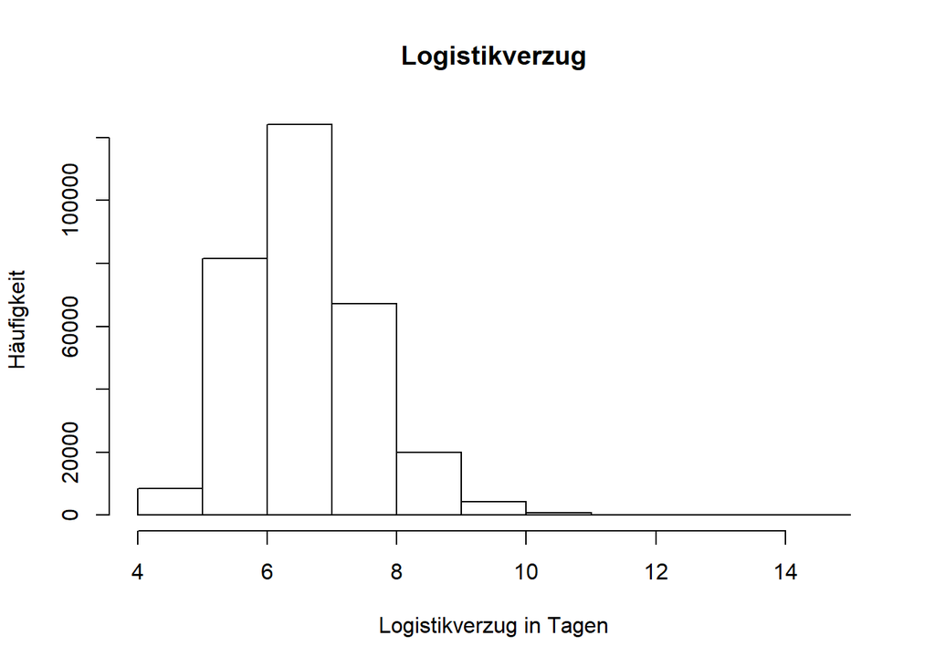

```r
h <- hist(x, breaks = 10, main = "Logistikverzug", xlab = "Logistikverzug in Tagen", ylab = "Häufigkeit")
```

Dem Histogram zufolge könnte es sich um eine Normalverteilung handeln. Um dies zu bestätigen wird ein QQ-Plot erstellt. Jedoch ergeben die Punkte im QQ-Plot keine Gerade, somit handelt es sich hier um keine Normalverteilung.

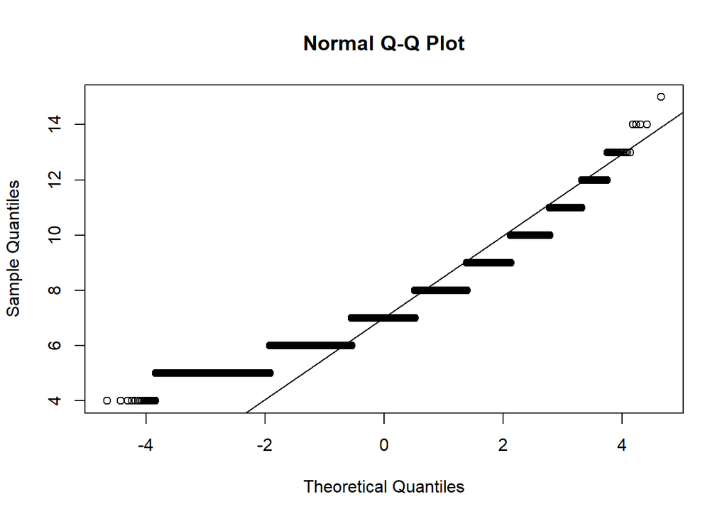

```r
qqnorm(x)
qqline(x)
```

Da es sich nicht um eine Normalverteilung handelt, muss nun herausgefunden werden welche Verteilung die Daten am besten repräsentiert. Dafür wird ein Cullen und Frey Graph geplottet, um herauszufinden welche Verteilungen gut passen.

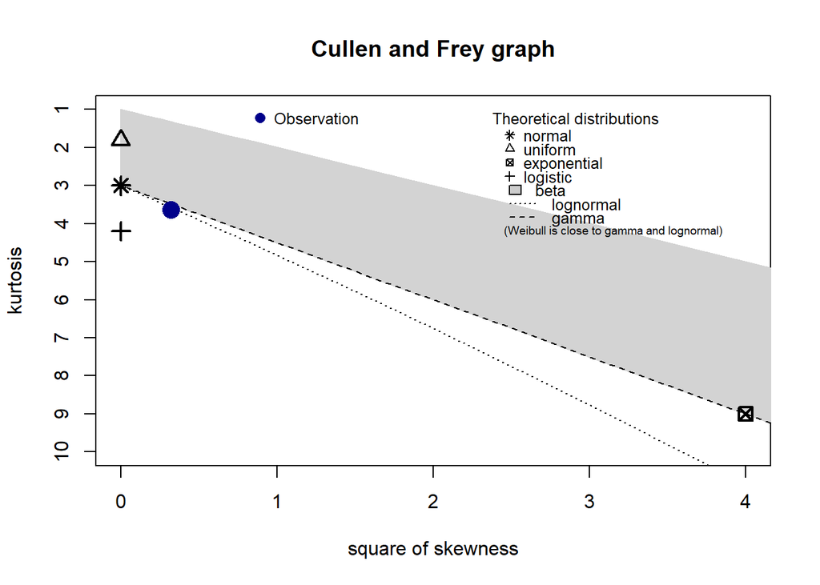

```
## summary statistics
## ------
## min:  4   max:  15
## median:  7
## mean:  7.080437
## estimated sd:  1.012302
## estimated skewness:  0.5674067
## estimated kurtosis:  3.630055
```

```r
descdist(x, discrete=FALSE)
```

Dem Graphen zufolge passen die logarithmische Normalverteilung, die Gammaverteilung und die Weibullverteilung ganz gut zu den Daten. Nun werden die drei Verteilungen daraufhin geprüft, wie gut sie zu den Daten passen und miteinander verglichen.

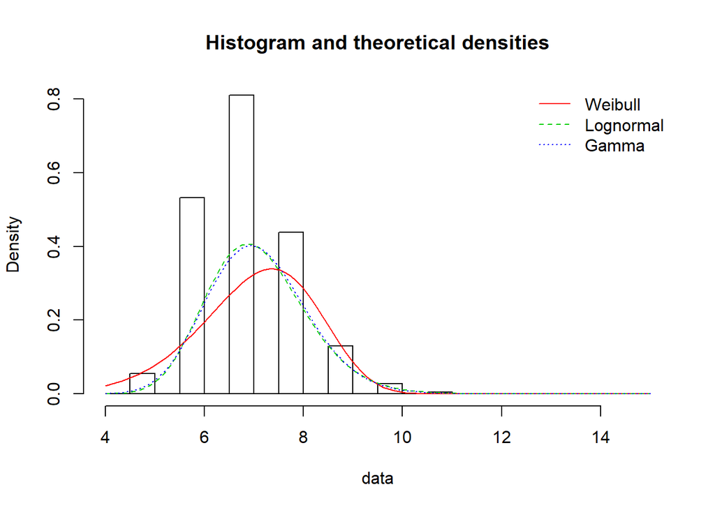

```r
p <- fitdist(x, "weibull")
p2 <- fitdist(x, "lnorm")
p3 <- fitdist(x, "gamma")

denscomp(list(p, p2, p3), legendtext = c("Weibull", "Lognormal", "Gamma"))
```

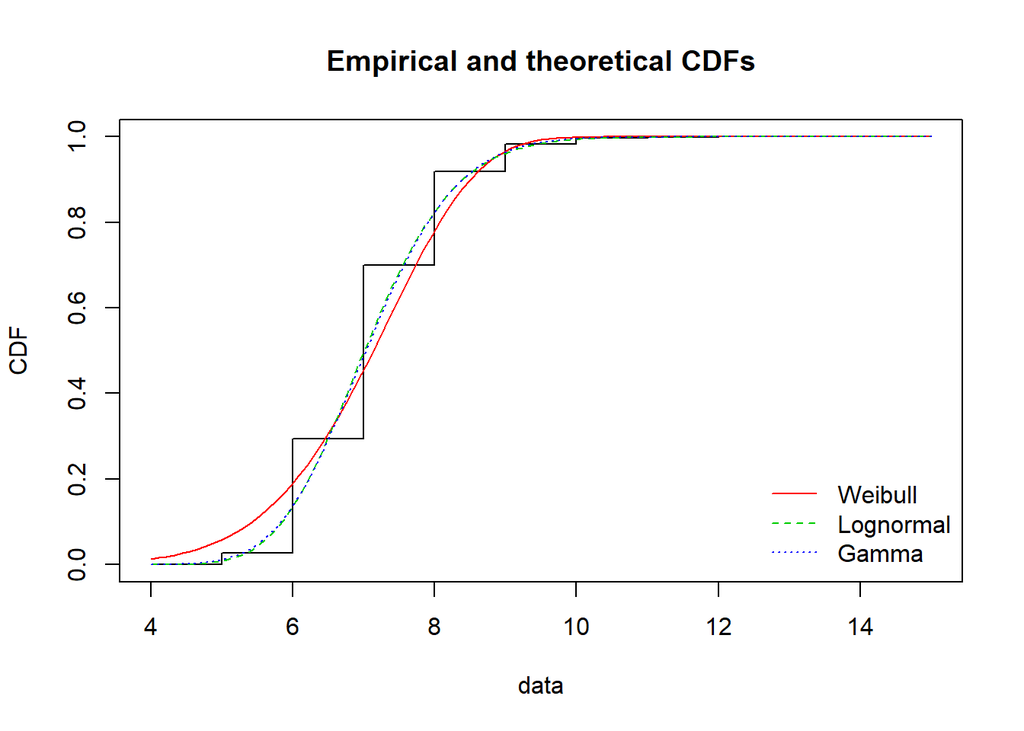

```r
cdfcomp(list(p, p2, p3), legendtext = c("Weibull", "Lognormal", "Gamma"))
```

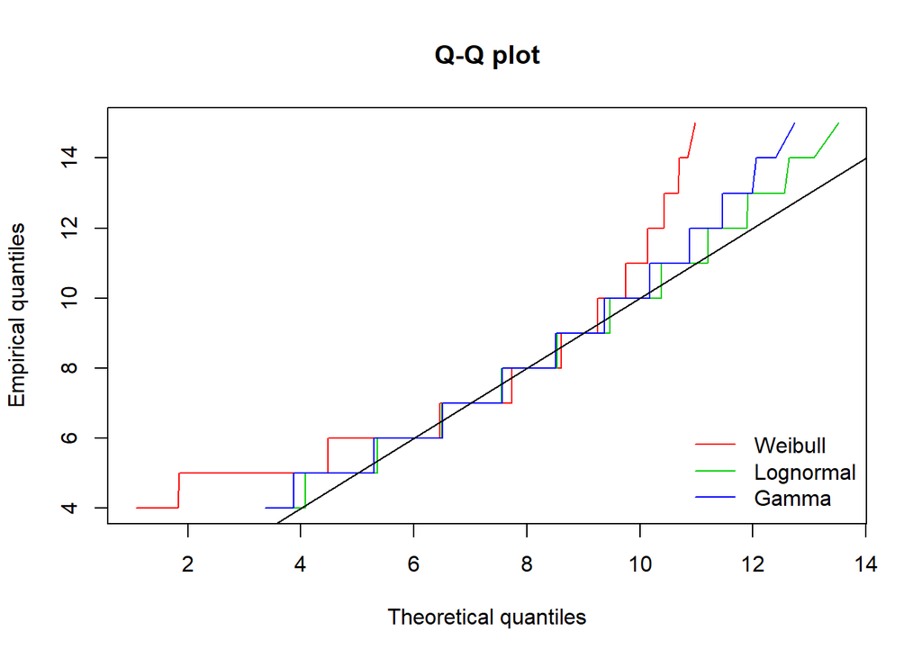

```r
qqcomp(list(p, p2, p3), legendtext = c("Weibull", "Lognormal", "Gamma"))
```

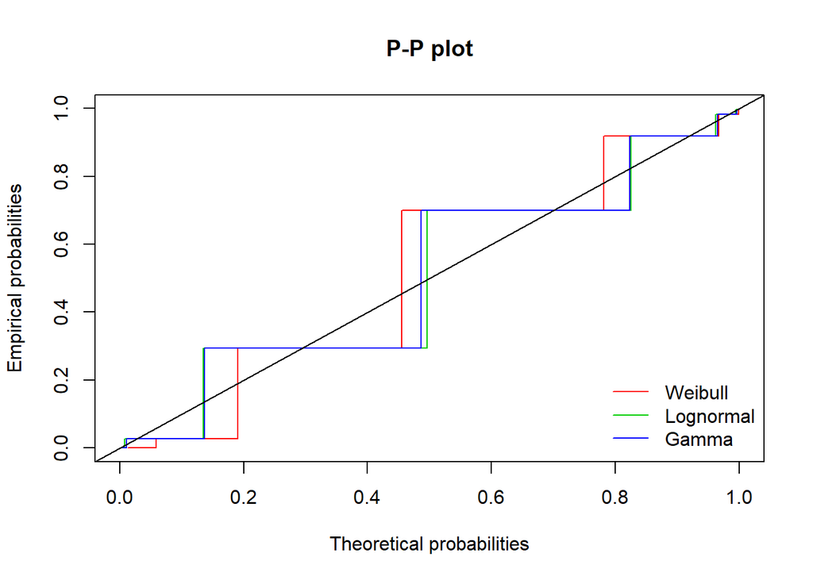

```r
ppcomp(list(p, p2, p3), legendtext = c("Weibull", "Lognormal", "Gamma"))
```

Anhand der Graphen kann man ablesen, dass die Weibullverteilung nicht passt, denn die Punkte des QQ-Plots ergeben keine Gerade. Die anderen beiden Verteilungen repräsentieren die Daten aber ganz gut. Dies sieht man am QQ-Plot, denn die Punkte beider Verteilungen ergeben eine Gerade. Beim Vergleich stellt sich heraus, dass die logarithmische Normalverteilung am besten passt, denn beim QQ-Plot sind die Punkte der logarithmischen Normalverteilung näher an der Geraden.

### Teilaufgabe b

**Wie viel Zeit vergeht mindestens/höchstens zwischen Warenausgang und Wareneingang?**

Das Maximum und Minimum des Logistikverzuges wird berechnet.

```r
max <- max(x)
min <- min(x)
```

Es vergehen zwischen Warenausgang und Wareneingang mindestens 4 und höchstens 15 Tage.

### Teilaufgabe c

**Bestimmen Sie den Mittelwert des Logistikverzugs.**

Der Durchschnitt des Logistikverzuges wird berechnet.

```r
mean <- mean(x)
```

Der Durchschnitt des Logistikverzuges beträgt 7.0804366 Tage.

### Teilaufgabe d

**Stellen Sie die Verteilung in geeigneter Weise dar.**

Wir stellen die Verteilung als Histogram mittels *ggplot* dar. Dabei wird ein Untertitel verwendet, der angibt in welchen Zeitraum der Logistikverzug betrachtet wird. Dafür muss das älteste Datum und das jüngste Datum extrahiert und umformatiert werden. Für das Histogramm wird noch die Häufigkeit des Logistikverzuges angezeigt, denn bei sehr kleinen Daten kann man das nicht auf dem Histogramm ablesen. Die x-Achse wird nur auf die relevante Spanne eingeschränkt, also dem Minimum und Maximum des Logistikverzuges.

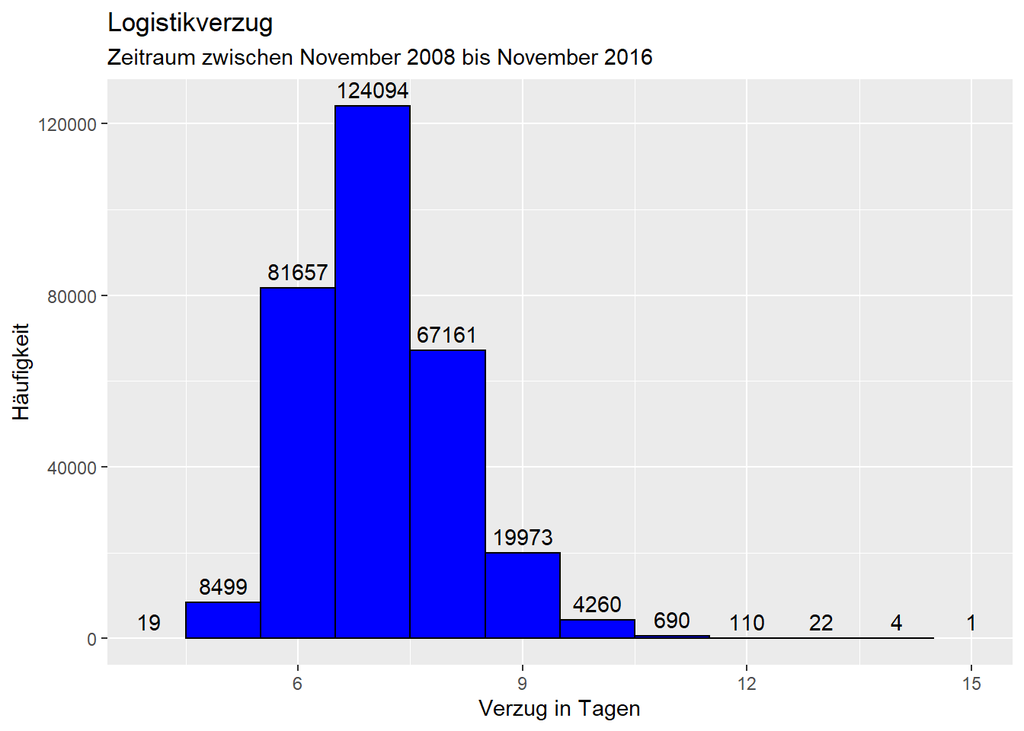

```r
#String für den Untertitel
min_datum <- format(min(Logistikverzug$Produktionsdatum), "%B %Y")
max_datum <- format(max(Logistikverzug$Wareneingang), "%B %Y")
time <- paste("Zeitraum zwischen", min_datum, "bis", max_datum, sep = " ")

ggplot(Logistikverzug, aes(x = Verzug)) +
  geom_histogram(binwidth = 1, fill = "blue", color = "black", na.rm = TRUE,  position="identity") +
  stat_bin(aes(y=..count.., label=..count..), geom="text", vjust=-.5, binwidth = 1) +
  xlim(4, 15)+
  labs(title = "Logistikverzug", subtitle = time, x = "Verzug in Tagen", y = "Häufigkeit")
```

# Aufgabe 2

**Warum ist es sinnvoll, die Ihnen bereitgestellten Daten in separaten Dateien abzulegen und nicht alles in einer riesigen Tabelle abzuspeichern?**

Damit dies zum einen Redundanz verhindert, denn wenn man alles in einer großen Tabelle abspeichert, werden viele Werte mehrfach in der Tabelle auftauchen. Und zum anderen ist die Laufzeit beim Suchen von Werten in einer großen, langen Tabelle sehr schlecht, denn angenommen man sucht einen Wert der als aller letztes in der Tabelle gespeichert ist, dann hätte man eine Laufzeit von n, wobei n die Anzahl der Einträge in der Tabelle sind. Dies könnte zu einem Problem bei großen n werden, denn dann hat man eine schlechte Laufzeit, nur um einen Wert zu extrahieren.

**Wie nennt sich das zugrunde liegende Datenbankkonzept?**

Dieses Konzept nennt sich Relationale Datenbank.

# Aufgabe 3

**Wie viele der Komponenten K7 landeten in Fahrzeugen, die in Köln zugelassen wurden?**

Da uns nur die Fahrzeuge interessieren, die in Köln zugelassen wurden, werden die Zulassungen nach der Gemeinde Köln gefiltert. Da nicht alle Komponenten in Fahrzeuge eingebaut wurden, müssen diese auch gefiltert werden. Dazu werden erstmal alle Bestandteile, die in Fahrzeugen verbaut wurden, in eine Tabelle zusammengefügt. Danach werden die Fahrzeuge gefiltert, indem nur Fahrzeuge, die eine K7 Komponente verbaut haben, bestehen bleiben. Zum Schluss müssen noch die Fahrzeuge und die Zulassungen in der Gemeinde Köln verknüpft werden. Dabei sollen nur die Fahrzeuge erhalten bleiben, die sowohl eine K7 Komponente verbaut haben als auch in Köln zugelassen wurden. Die Anzahl der Fahrzeuge, die die Bedingungen erfüllen, ergibt sich aus der Anzahl der Zeilen in der Tabelle.

```r
#Zulassungen nach Koeln filtern
zulassungen_koeln <- zulassungen_aller_Fahrzeuge %>%
  filter(Gemeinden == "KOELN") %>%
  select(-Zulassung)

#join Bestandteile in eine Tabelle
bestandteile <- bind_rows(bestandteile_oem1_typ11, bestandteile_oem1_typ12) %>%
  bind_rows(bestandteile_oem2_typ21) %>%
  bind_rows(bestandteile_oem2_typ22) %>%
  select(ID_Karosserie, ID_Fahrzeug)

#join K7 und Bestandteile, und dies dann nochmal mit zulassungen joinen
zugelassene_k7_fahrzeuge <- inner_join(komponente_k7, bestandteile, by = c("IDNummer" = "ID_Karosserie")) %>%
  inner_join(zulassungen_koeln, by = c("ID_Fahrzeug" = "IDNummer"))
```

Es wurden 7614 der Komponenten K7 in Fahrzeugen verbaut, die in Köln zugelassen wurden.

# Aufgabe 4

**Welche Datentypen haben die Attribute der Zulassungstabelle „Zulassungen_aller_Fahrzeuge“?**

Es wird ein Überblick über die Struktur der Daten gemacht.

```r
str(zulassungen_aller_Fahrzeuge)
```

```
## Classes 'spec_tbl_df', 'tbl_df', 'tbl' and 'data.frame': 3204104 obs. of  4 variables:
##  $ X1       : num  408097 408098 1 2 3 ...
##  $ IDNummer : chr  "11-1-11-1" "11-1-11-2" "12-1-12-1" "12-1-12-2" ...
##  $ Gemeinden: chr  "DRESDEN" "DRESDEN" "LEIPZIG" "LEIPZIG" ...
##  $ Zulassung: Date, format: "2009-01-01" "2009-01-01" ...
##  - attr(*, "spec")=
##   .. cols(
##   ..   X1 = col_double(),
##   ..   IDNummer = col_character(),
##   ..   Gemeinden = col_character(),
##   ..   Zulassung = col_date(format = "")
##   .. )
```

Das Attribut von *X1* hat den Datentypen *col_double*.  
Das Attribut von *IDNummer* hat den Datentypen *col_character*.  
Das Attribut von *Gemeinden* hat den Datentypen *col_character*.  
Das Attribut von *Zulassung* hat den Datentypen *col_date*.

# Aufgabe 5

**Sie wollen Ihre Applikation veröffentlichen. Warum ist es gerade dann sinnvoll die Datensätze auf der Datenbank eines Servers abzulegen? Warum können Sie die Datensätze nicht auf Ihrem persönlichen Computer ablegen?**

Angenommen die Applikation würde ständig auf die Datensätze zugreifen müssen: Wenn die Datensätze dann nur lokal auf einem persönlichen Computer gespeichert sind, sind sie für die veröffentlichte Applikation nicht jederzeit zugreifbar, da ein persönlicher Computer i.d.R. nicht dauerhaft aktiv ist bzw. kann ein dauerhafter Betrieb seltener gewährleistet werden.

**Nennen Sie eine einfache Möglichkeit Ihre Applikation ihrem Kundenkreis zugänglich zu machen?**

Die Applikation kann auf einer Webseite oder in einem App-Store dem Kundenkreis zugänglich gemacht werden.

# Aufgabe 6

**Am 11.08.2010 hat es einen Unfall mit Fahrerflucht gegeben. Von dem Kennzeichen des Unfallwagens fehlt jede Spur. Die Polizei bittet Sie um Hilfe, da Sie für das Kraftfahrtbundesamt arbeiten und fragt, wo das Fahrzeug mit der Karosseriebauteilnummer „K4-112-1121-23“ zugelassen wurde.**

Um das Bauteil zu finden, werden erst einmal alle Bestandteile der Fahrzeuge in einer Tabelle zusammengefügt, damit diese nach dem gesuchten Bauteil gefiltert werden kann. Nun muss noch herausgefunden werden, wo das Fahrzeug mit dem gesuchten Bauteil zugelassen wurde. Da ein Bauteil nur in einem Fahrzeug verbaut sein kann, reicht es, wenn man die Zulassungen aller Fahrzeuge mit den zuvor gefilterten Daten zusammenfügt. Der Ort, an dem dieses Fahrzeug zugelassen wurde, steht in der Spalte *Gemeinden*. Jedoch sind die Character-Strings der Gemeinde alle in Großbuchstaben geschrieben. Dies muss in die richtige Rechtschreibung konvertiert werden.

```r
bestandteil_k4_112_1121_23 <- bind_rows(bestandteile_oem1_typ11, bestandteile_oem1_typ12) %>%
  bind_rows(bestandteile_oem2_typ21) %>%
  bind_rows(bestandteile_oem2_typ22) %>%
  filter(ID_Karosserie == "K4-112-1121-23") %>%
  left_join(zulassungen_aller_Fahrzeuge, by = c("ID_Fahrzeug" = "IDNummer"))

ort <- bestandteil_k4_112_1121_23$Gemeinden
ort <- paste(substring(ort, 1, 1), tolower(substring(ort, 2, str_length(ort))), sep = "")
```

Das Fahrzeug mit der Karosseriebauteilnummer „K4-112-1121-23“ wurde in Radeberg zugelassen.